```r
# Clear workspace and free memory
rm(list = ls())
```

## Analysis of NYC Taxi Data

In this document, we investigate public NYC taxi data. The data can be downloaded from the following links:

https://drive.google.com/file/d/0B3o2JsiUpwEvLTRDNkEyZmZZM1U/view?usp=sharing

https://drive.google.com/file/d/0B3o2JsiUpwEvSlU2RFVHZUJZeFk/view?usp=sharing

There are two CSV files for data and fare. They are big files and ~2.5GB and ~1.7GB respectively.

[figure not shown]

We used R software to analyze the data. R is free and can be installed as follows:

https://github.com/genomicsclass/windows#installing-r

The number of rows in each file are as follows:

```r
# # install.packages("sqldf")
# library(sqldf)
# # Calculate the number of records in SQL fashion. The csv file will not be loaded to the memory. Very slow.
# read.csv.sql("trip_data_4.csv", sql = "select count(medallion) from file")
# read.csv.sql("trip_fare_4.csv", sql = "select count(medallion) from file")
```

And the header information of the two tables are:

```r
# In this analysis we assume the platform has memory constrain and we don't load full data to RAM.
# Read the headers of the two files
# scan("trip_data_4.csv", nlines = 1, what = character())
# scan("trip_fare_4.csv", nlines = 1, what = character())
```

Based on the information we can sumarizes the following:

```r
# [1] "record_id"          "medallion"          "hack_license"       "vendor_id"          "rate_code"
# [6] "store_and_fwd_flag" "pickup_datetime"    "dropoff_datetime"   "passenger_count"    "trip_time_in_secs"
#[11] "trip_distance"      "pickup_longitude"   "pickup_latitude"    "dropoff_longitude"  "dropoff_latitude"
#[16] "payment_type"       "fare_amount"        "surcharge"          "mta_tax"            "tip_amount"
#[21] "tolls_amount"       "total_amount"
```

Most of the header names are self descriptive. Some of the special names are:

1. Each car has a medallion (a badge) to uniquely identify the taxi.
2. The hack license is for the driver which authorizes the driver to drive a taxicab.
3. The vendor id is the electronic system assigned to the taxi such as Verifone Transportation Systems (VTS), Mobile Knowledge Systems Inc (CMT), etc.
4. The rate code is a taximeter rate category which is assigned by an authority.

Since the CSV files are large, processing it without a database technology is very slow. Therefore, we used free MySQL database to clean and query the data as fast as possible. My SQL installer can be downloaded from the following link.

https://dev.mysql.com/downloads/installer/

Once installed, we have changed the following parameter,

innodb_buffer_pool_size=500M

in the “.ini” file to fast process the big files. By default, it is 11M which is small.

We have created two tables and uploaded the 2 CSV files. The database is created by default as sakila. The 2 tables we created are tb_nyt_data and tb_nyt_fare. We created the tables using GUI as follows:

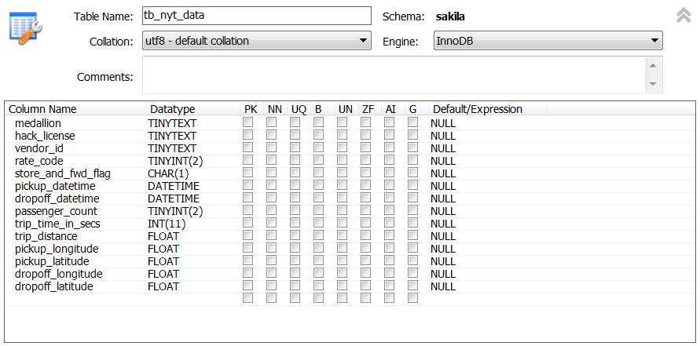

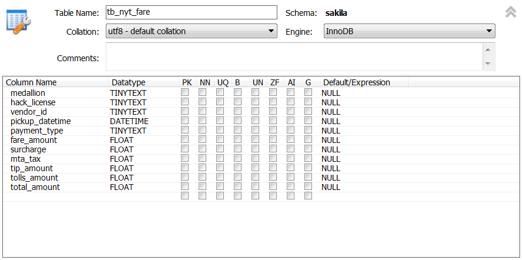

However, they can be created by SQL transactions as follows:

CREATE TABLE `tb_nyt_data` (  
`medallion` tinytext,  
`hack_license` tinytext,  
`vendor_id` tinytext,  
`rate_code` tinyint(2) DEFAULT NULL,  
`store_and_fwd_flag` char(1) DEFAULT NULL,  
`pickup_datetime` datetime DEFAULT NULL,  
`dropoff_datetime` datetime DEFAULT NULL,  
`passenger_count` tinyint(2) DEFAULT NULL,  
`trip_time_in_secs` int(11) DEFAULT NULL,  
`trip_distance` float DEFAULT NULL,  
`pickup_longitude` float DEFAULT NULL,  
`pickup_latitude` float DEFAULT NULL,  
`dropoff_longitude` float DEFAULT NULL,  
`dropoff_latitude` float DEFAULT NULL  
) ENGINE=InnoDB DEFAULT CHARSET=utf8;

and

CREATE TABLE `tb_nyt_fare` (  
`medallion` tinytext,  
`hack_license` tinytext,  
`vendor_id` tinytext,  
`pickup_datetime` datetime DEFAULT NULL,  
`payment_type` tinytext,  
`fare_amount` float DEFAULT NULL,  
`surcharge` float DEFAULT NULL,  
`mta_tax` float DEFAULT NULL,  
`tip_amount` float DEFAULT NULL,  
`tolls_amount` float DEFAULT NULL,  
`total_amount` float DEFAULT NULL  
) ENGINE=InnoDB DEFAULT CHARSET=utf8;

as well. The SQL commands can be issued via MySQL client as follow.

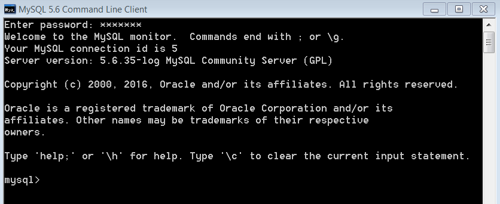

After creating the tables in the database, we have uploaded the large CSV files to their respective tables. Following are the respective 2 SQL queries.

TRUNCATE sakila.tb_nyt_data;  
LOAD DATA LOCAL INFILE ‘trip_data_4.csv’  
IGNORE INTO TABLE sakila.tb_nyt_data  
FIELDS TERMINATED BY ‘,’  
LINES TERMINATED BY ‘’  
IGNORE 1 LINES;

TRUNCATE sakila.tb_nyt_fare;  
LOAD DATA LOCAL INFILE ‘trip_fare_4.csv’  
IGNORE INTO TABLE sakila.tb_nyt_fare  
FIELDS TERMINATED BY ‘,’  
LINES TERMINATED BY ‘’  
IGNORE 1 LINES;

Next have counted the number of records in each table as follow:

mysql> select count(medallion) from sakila.tb_nyt_data;  
+——————+  
| count(medallion) |  
+——————+  
| 15100468 |  
+——————+  
1 row in set (14.98 sec)

mysql> select count(medallion) from sakila.tb_nyt_fare;  
+——————+  
| count(medallion) |  
+——————+  
| 15100468 |  
+——————+  
1 row in set (14.90 sec)

Now we have to check whether the common fields of both tables are identical so we can merge the 2 tables. We already know that both tables have the same number of records. Comparison of a large table is time-consuming without a unique index column. Therefore, we add an index column (i.e., record_id) to both tables as follows:

ALTER TABLE sakila.tb_nyt_data ADD COLUMN record_id INT AUTO_INCREMENT UNIQUE FIRST;

ALTER TABLE sakila.tb_nyt_fare ADD COLUMN record_id INT AUTO_INCREMENT UNIQUE FIRST;

Now we have an index in the tables. Since there are a lot of records, comparing an entire column is time-consuming. Therefore, we randomly selected few rows in both tables and compared the common columns. Following is the result of comparing 5 random ‘medallion’ and ‘pickup_datetime’.

SELECT sakila.tb_nyt_data.medallion, sakila.tb_nyt_data.pickup_datetime, GROUP_CONCAT(sakila.tb_nyt_fare.medallion, sakila.tb_nyt_fare.pickup_datetime)  
FROM sakila.tb_nyt_data  
LEFT JOIN sakila.tb_nyt_fare  
ON sakila.tb_nyt_data.record_id = sakila.tb_nyt_fare.record_id  
GROUP BY sakila.tb_nyt_data.record_id  
ORDER BY RAND() LIMIT 5;

| medallion | pickup_datetime | GROUP_CONCAT(sakila.tb_nyt_fare.medallion, sakila.tb_nyt_fare.pickup_datetime) |
| --- | --- | --- |
| 1FB2BF12B504498BC8B7B860294CD372 38A7CAA4DAC9F9BA44AF2621988B1D27 0FB2153FD9CF9B210B0C68D9986BA692 036FCBDB6ABA5E1E578FA85E377A454D C904476CB6A88781EDCB3A453C6A9028 | 2013-04-04 18:12:00 2013-04-11 12:58:00 2013-04-24 21:37:00 2013-04-27 16:04:37 2013-04-18 03:50:19 | 1FB2BF12B504498BC8B7B860294CD3722013-04-04 18:12:00 38A7CAA4DAC9F9BA44AF2621988B1D272013-04-11 12:58:00 0FB2153FD9CF9B210B0C68D9986BA6922013-04-24 21:37:00 036FCBDB6ABA5E1E578FA85E377A454D2013-04-27 1… |

Since a given car in a given pickup time uniquely identify an event, having the same value in random locations determine the rows in 2 tables are 1 to 1 related.

Since the two tables have identical common columns, we can join the two tables. Joining the tables is fast with the index key ‘record_id’. The new table ‘tb_nyt_comb’ was created using the following MySQL query.

CREATE TABLE `tb_nyt_comb` (  
`record_id` INT NOT NULL,  
`medallion` TINYTEXT NULL,  
`hack_license` TINYTEXT NULL,  
`vendor_id` TINYTEXT NULL,  
`rate_code` TINYINT(4) NULL DEFAULT NULL,  
`store_and_fwd_flag` CHAR(1) NULL DEFAULT NULL,  
`pickup_datetime` DATETIME NULL DEFAULT NULL,  
`dropoff_datetime` DATETIME NULL DEFAULT NULL,  
`passenger_count` TINYTEXT NULL,  
`trip_time_in_secs` INT(11) NULL DEFAULT NULL,  
`trip_distance` FLOAT NULL DEFAULT NULL,  
`pickup_longitude` FLOAT NULL DEFAULT NULL,  
`pickup_latitude` FLOAT NULL DEFAULT NULL,  
`dropoff_longitude` FLOAT NULL DEFAULT NULL,  
`dropoff_latitude` FLOAT NULL DEFAULT NULL,  
`payment_type` TINYTEXT NULL,  
`fare_amount` FLOAT NULL DEFAULT NULL,  
`surcharge` FLOAT NULL DEFAULT NULL,  
`mta_tax` FLOAT NULL DEFAULT NULL,  
`tip_amount` FLOAT NULL DEFAULT NULL,  
`tolls_amount` FLOAT NULL DEFAULT NULL,  
`total_amount` FLOAT NULL DEFAULT NULL,  
PRIMARY KEY (record_id)  
)  
ENGINE=InnoDB;

Then the data was inserted into new table from ‘tb_nyt_data’ and ‘tb_nyt_fare’ using the indexing.

INSERT INTO sakila.tb_nyt_comb  
(record_id,  
medallion,  
hack_license,  
vendor_id,  
rate_code,  
store_and_fwd_flag,  
pickup_datetime,  
dropoff_datetime,  
passenger_count,  
trip_time_in_secs,  
trip_distance,  
pickup_longitude,  
pickup_latitude,  
dropoff_longitude,  
dropoff_latitude,  
payment_type,  
fare_amount,  
surcharge,  
mta_tax,  
tip_amount,  
tolls_amount,  
total_amount)  
SELECT  
sakila.tb_nyt_data.record_id,  
sakila.tb_nyt_data.medallion,  
sakila.tb_nyt_data.hack_license,  
sakila.tb_nyt_data.vendor_id,  
sakila.tb_nyt_data.rate_code,  
sakila.tb_nyt_data.store_and_fwd_flag,  
sakila.tb_nyt_data.pickup_datetime,  
sakila.tb_nyt_data.dropoff_datetime,  
sakila.tb_nyt_data.passenger_count,  
sakila.tb_nyt_data.trip_time_in_secs,  
sakila.tb_nyt_data.trip_distance,  
sakila.tb_nyt_data.pickup_longitude,  
sakila.tb_nyt_data.pickup_latitude,  
sakila.tb_nyt_data.dropoff_longitude,  
sakila.tb_nyt_data.dropoff_latitude,  
sakila.tb_nyt_fare.payment_type,  
sakila.tb_nyt_fare.fare_amount,  
sakila.tb_nyt_fare.surcharge,  
sakila.tb_nyt_fare.mta_tax,  
sakila.tb_nyt_fare.tip_amount,  
sakila.tb_nyt_fare.tolls_amount,  
sakila.tb_nyt_fare.total_amount  
FROM  
sakila.tb_nyt_data  
INNER JOIN  
sakila.tb_nyt_fare  
ON  
sakila.tb_nyt_data.record_id = sakila.tb_nyt_fare.record_id;

Once we combined the 2 tables, we damped 100000 random records for statistical analysis. The MySQL query to dump the data is as follows:

SELECT * FROM sakila.tb_nyt_comb  
GROUP BY sakila.tb_nyt_comb.record_id  
ORDER BY RAND() LIMIT 100000  
INTO OUTFILE ‘C:/temp/results.csv’  
FIELDS TERMINATED BY ‘,’  
LINES TERMINATED BY ‘’;

Note that for this to be sucessful, MySQL “.ini”" file should be changed as follows,

Secure File Priv.  
secure-file-priv=“C:/temp”  
[mysqld]  
tmpdir=C:/temp

and restart the MySQL service. Then following MySQL query should be like this:

SHOW VARIABLES LIKE ‘secure_file_priv’;  
+——————+———-+  
| Variable_name | Value |  
+——————+———-+  
| secure_file_priv | C: |  
+——————+———-+

Note that from now on our new CSV file has following headers consecutively,

record_id  
medallion  
hack_license  
vendor_id  
rate_code  
store_and_fwd_flag  
pickup_datetime  
dropoff_datetime  
passenger_count  
trip_time_in_secs  
trip_distance  
pickup_longitude  
pickup_latitude  
dropoff_longitude  
dropoff_latitude  
payment_type  
fare_amount  
surcharge  
mta_tax  
tip_amount  
tolls_amount  
total_amount

with 100000 records.

## Analysis of NYC Taxi Data

In this section, we study 10,000 random samples from our 100,000 sample records file. We haven’t applied Bootstrap techniques in here for simplicity. The bootstrap method is applied to the next section where the modeling is performed.

```r
filename  <- "sampledData100000.csv";
Dat100000 <- read.csv(filename);
records     <- Dat100000[sample(1:nrow(Dat100000), 10000, replace=FALSE),]

library(e1071)
library(lubridate)
library(geosphere)
```

1.a) What is the distribution of a number of passengers per trip?

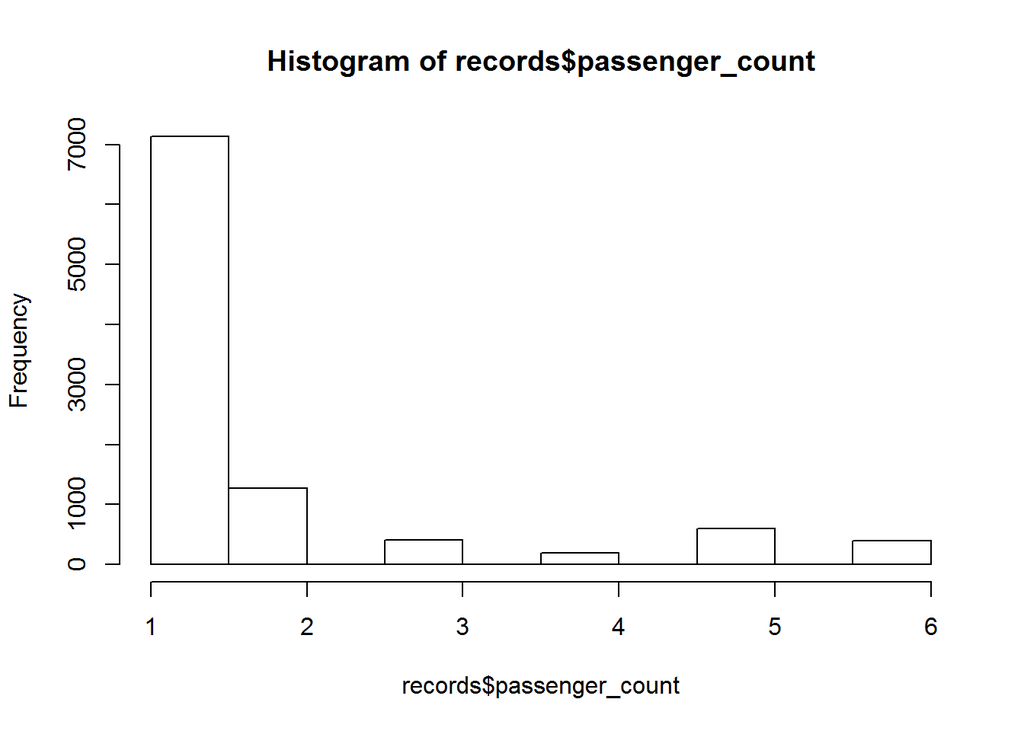

```r
hist(records$passenger_count)
```

```r
summary(records$passenger_count)
```

```
##    Min. 1st Qu.  Median    Mean 3rd Qu.    Max.
##   1.000   1.000   1.000   1.704   2.000   6.000
```

```r
skewness(records$passenger_count)
```

```
## [1] 2.022606
```

2. What is the distribution of payment_type?

Payment type is a discrete variable.

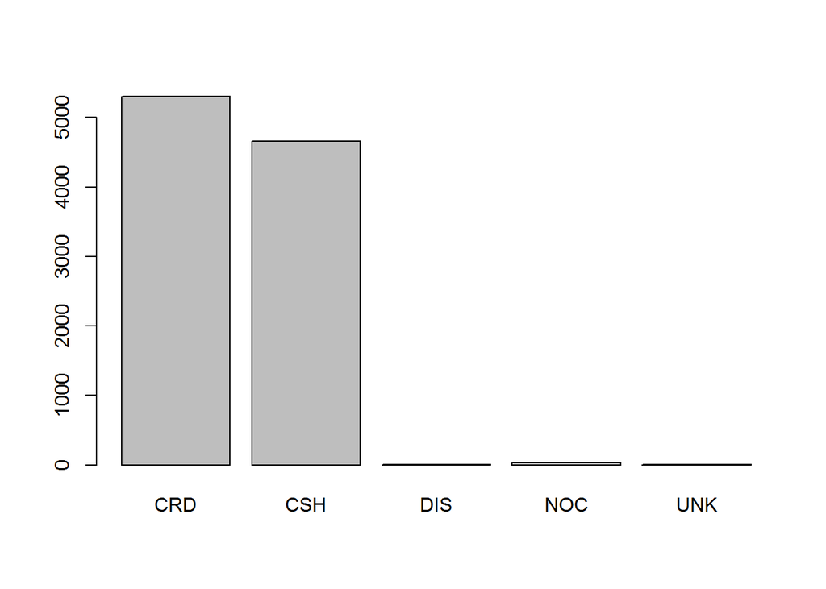

```r
barplot(table(records$payment_type))
```

Note: CRD - Card, CSH - Cash Most of the transactions are either by card or cash.

1.c) What is the distribution of fare amount?

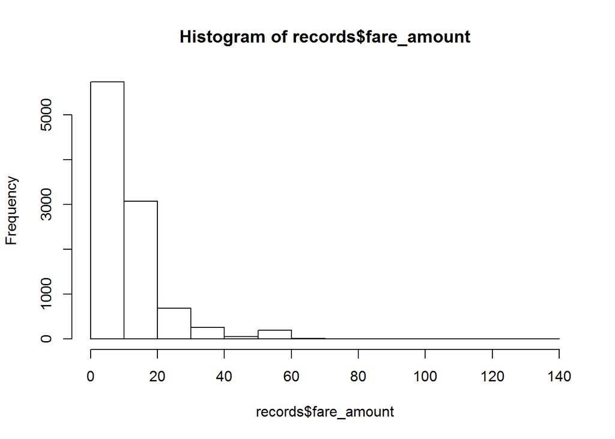

```r
hist(records$fare_amount)
```

```r
summary(records$fare_amount)
```

```
##    Min. 1st Qu.  Median    Mean 3rd Qu.    Max.
##    2.50    6.50    9.00   12.16   14.00  136.00
```

```r
skewness(records$fare_amount)
```

```
## [1] 3.032729
```

1.d) What is the distribution of tip amount?

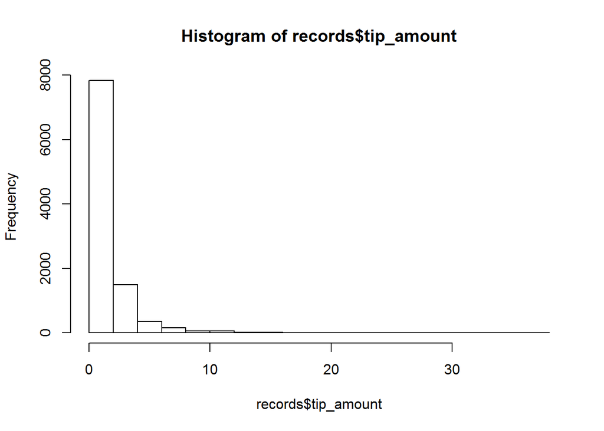

```r
hist(records$tip_amount)
```

```r
summary(records$tip_amount)
```

```
##    Min. 1st Qu.  Median    Mean 3rd Qu.    Max.
##   0.000   0.000   1.000   1.323   2.000  38.000
```

```r
skewness(records$tip_amount)
```

```
## [1] 4.08715
```

1.e) What is the distribution of total amount?

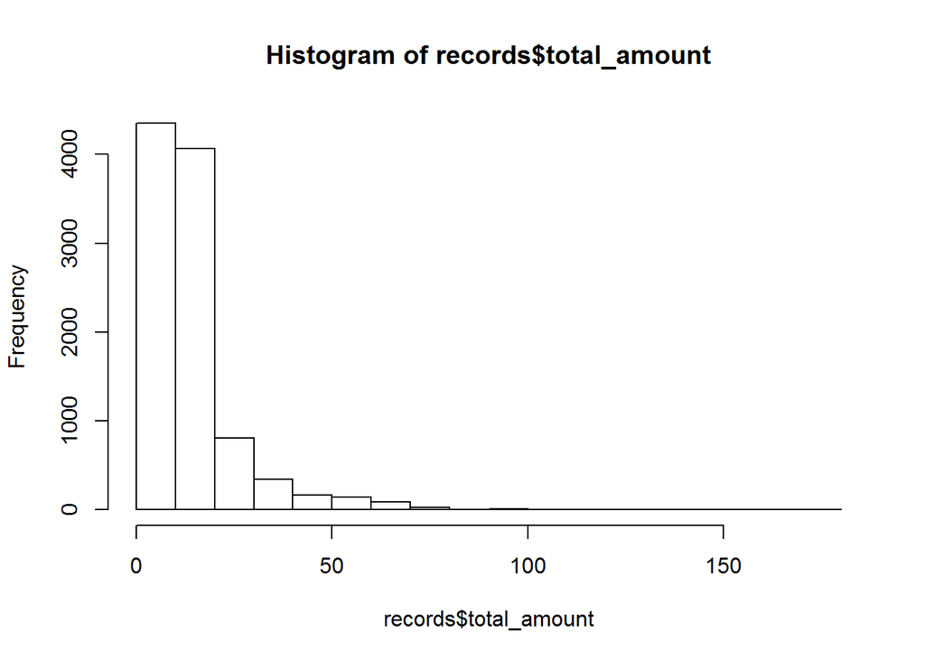

```r
hist(records$total_amount)
```

```r
summary(records$total_amount)
```

```
##    Min. 1st Qu.  Median    Mean 3rd Qu.    Max.
##    3.00    8.00   11.00   14.53   16.20  176.03
```

```r
skewness(records$total_amount)
```

```
## [1] 3.197226
```

1.f) What are top 5 busiest hours of the day?

It seems to be each day is different. We plot the busiest hour of each day.

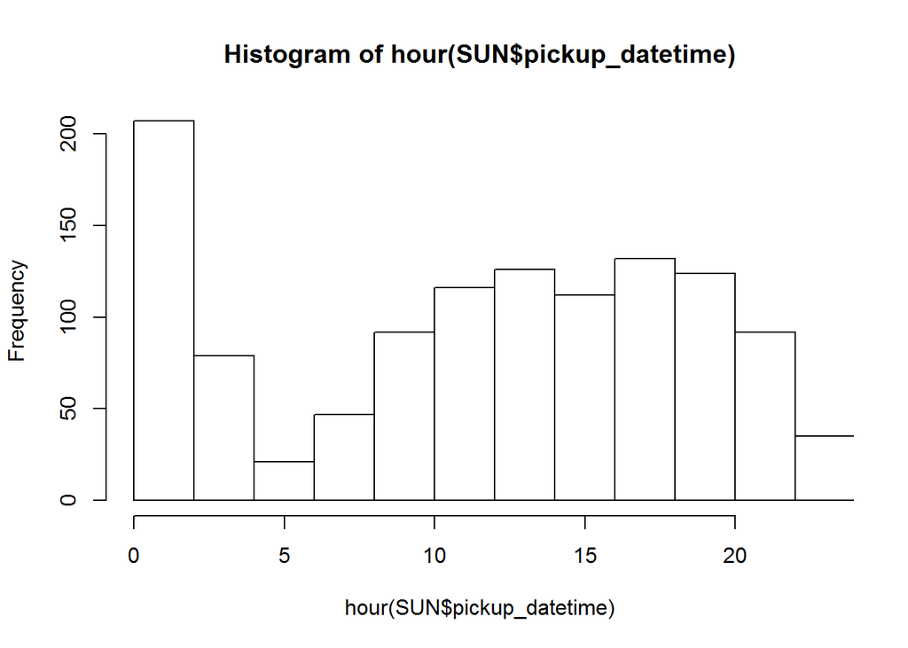

```r
records$pickup_datetime_transformed <- ymd_hms(records$pickup_datetime)

SUN <- records[wday(records$pickup_datetime_transformed) == 1,]
MON <- records[wday(records$pickup_datetime_transformed) == 2,]
TUE <- records[wday(records$pickup_datetime_transformed) == 3,]
WED <- records[wday(records$pickup_datetime_transformed) == 4,]
THU <- records[wday(records$pickup_datetime_transformed) == 5,]
FRI <- records[wday(records$pickup_datetime_transformed) == 6,]
SAT <- records[wday(records$pickup_datetime_transformed) == 7,]

#SUNDAY
hist(hour(SUN$pickup_datetime),xlim = c(0, 23))
```

```r
freqArraySun <- c(hour(SUN$pickup_datetime))
names(sort(summary(as.factor(freqArraySun)), decreasing=T)[1:5])
```

```
## [1] "18" "0"  "19" "1"  "14"
```

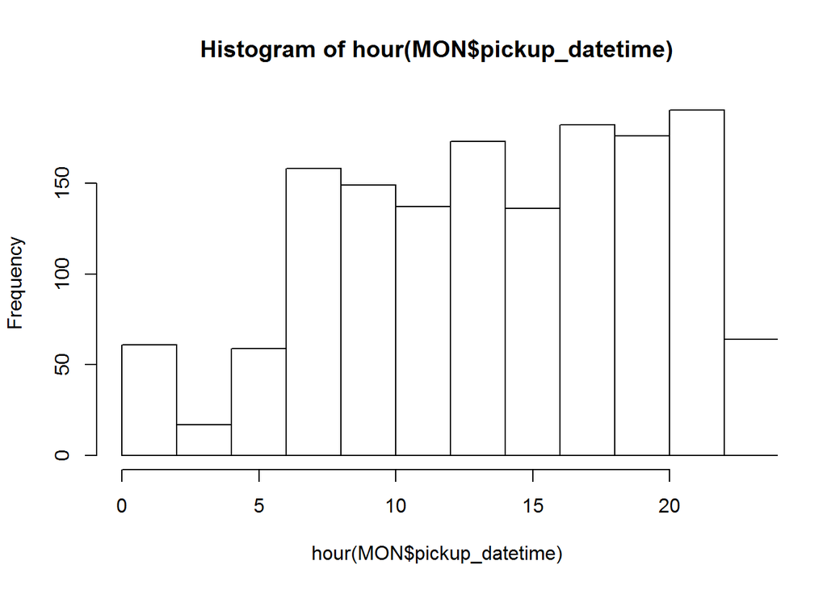

```r
# MONDAY
hist(hour(MON$pickup_datetime),xlim = c(0, 23))
```

```r
freqArrayMon <- c(hour(MON$pickup_datetime))
names(sort(summary(as.factor(freqArrayMon)), decreasing=T)[1:5])
```

```
## [1] "18" "21" "19" "14" "8"
```

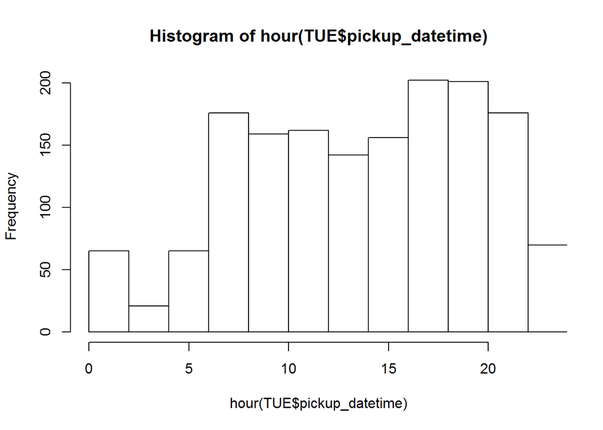

```r
# TUESDAY
hist(hour(TUE$pickup_datetime),xlim = c(0, 23))
```

```r
freqArrayTue <- c(hour(TUE$pickup_datetime))
names(sort(summary(as.factor(freqArrayTue)), decreasing=T)[1:5])
```

```
## [1] "18" "19" "22" "8"  "20"
```

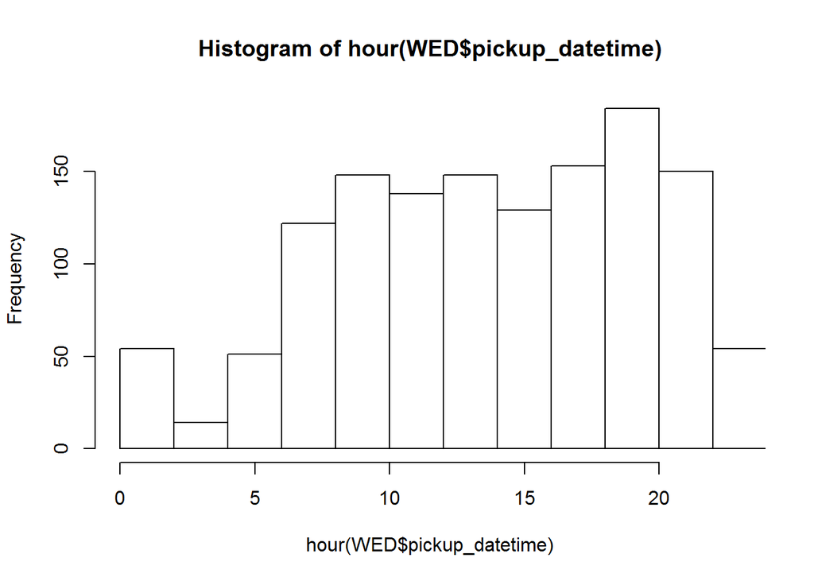

```r
# WEDNESDAY
hist(hour(WED$pickup_datetime),xlim = c(0, 23))
```

```r
freqArrayWed <- c(hour(WED$pickup_datetime))
names(sort(summary(as.factor(freqArrayWed)), decreasing=T)[1:5])
```

```
## [1] "19" "9"  "20" "18" "22"
```

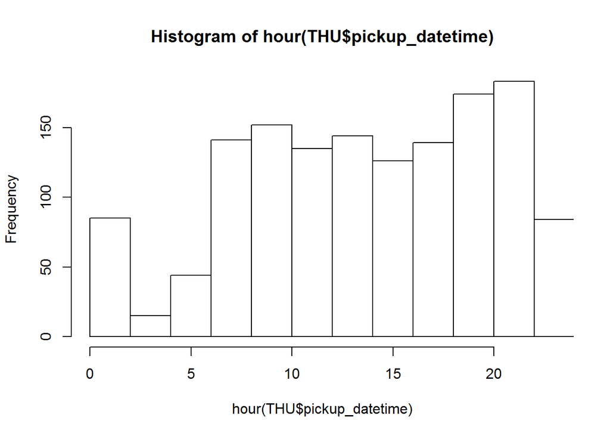

```r
# THURSDAY
hist(hour(THU$pickup_datetime),xlim = c(0, 23))
```

```r
freqArrayThu <- c(hour(THU$pickup_datetime))
names(sort(summary(as.factor(freqArrayThu)), decreasing=T)[1:5])
```

```
## [1] "22" "21" "20" "19" "23"
```

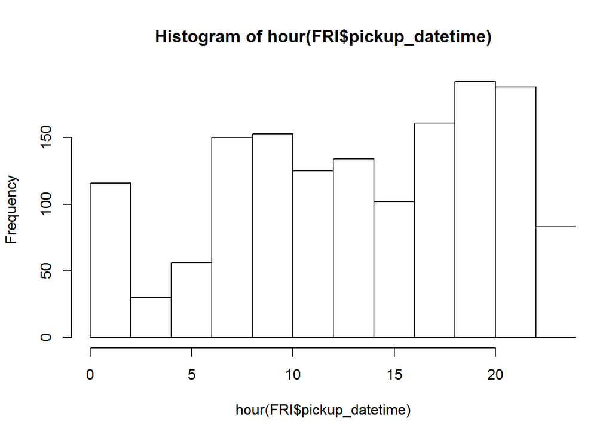

```r
# FRIDAY
hist(hour(FRI$pickup_datetime),xlim = c(0, 23))
```

```r
freqArrayFri <- c(hour(FRI$pickup_datetime))
names(sort(summary(as.factor(freqArrayFri)), decreasing=T)[1:5])
```

```
## [1] "20" "18" "22" "21" "19"
```

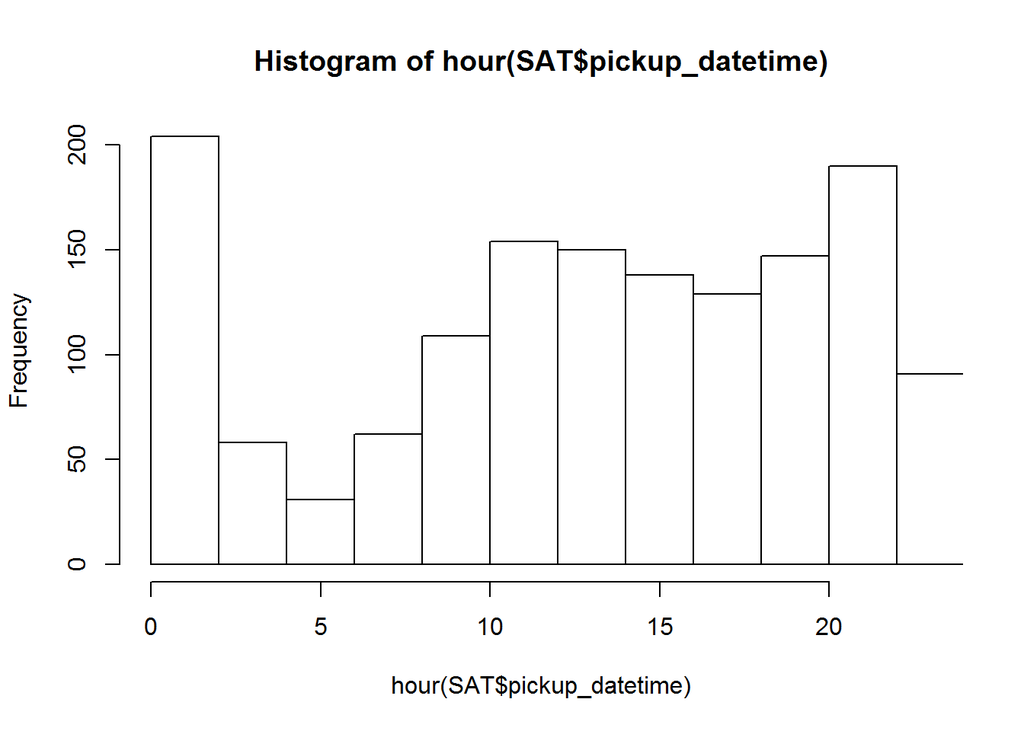

```r
# SATURDAY
hist(hour(SAT$pickup_datetime),xlim = c(0,23))
```

```r
freqArraySat <- c(hour(SAT$pickup_datetime))
names(sort(summary(as.factor(freqArraySat)), decreasing=T)[1:5])
```

```
## [1] "21" "23" "22" "0"  "20"
```

1.g) What are the top 10 busiest locations of the city?

To find this we perform K-mean clustering on pickup locations with 10 clusters. Then we identify the cluster centers as the busiest locations.

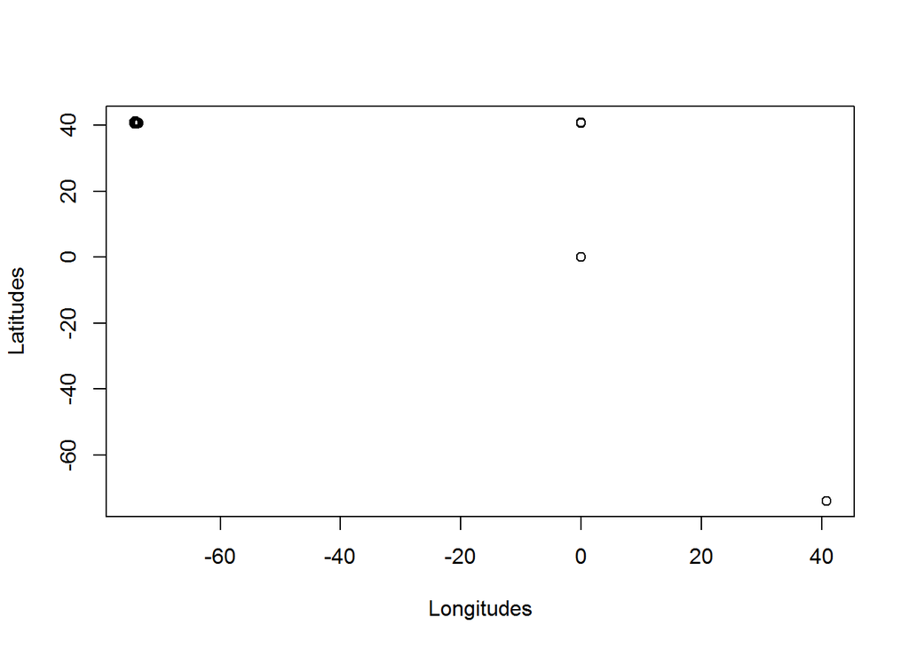

```r
# Let's clustering the GPS locations
pickLoc <- data.frame(pickLat=records$pickup_latitude,pickLon=records$pickup_longitude)
dropLoc <- data.frame(dropLat=records$dropoff_latitude,dropLon=records$dropoff_longitude)
pickLoc <- pickLoc[pickLoc$pickLat <= 90 & pickLoc$pickLat > -90, ]
pickLoc <- pickLoc[pickLoc$pickLon <= 180 & pickLoc$pickLon > -180, ]
dropLoc <- dropLoc[dropLoc$dropLat <= 90 & dropLoc$dropLat > -90, ]
dropLoc <- dropLoc[dropLoc$dropLon <= 180 & dropLoc$dropLon > -180, ]
x1 <- c(pickLoc$pickLon)
y1 <- c(pickLoc$pickLat)
x2 <- c(dropLoc$dropLon)
y2 <- c(dropLoc$dropLat)
x <- c(x1,x2)
y <- c(y1,y2)
gpsCordinates <- cbind(x,y)
plot(gpsCordinates, xlab="Longitudes", ylab="Latitudes")
```

I have just noticed some GPS points are zeros which are false. Some GPS locations are not in NYC. They have to be cleaned (outliers). To accurately clustering, we have to focus more on the high-density area

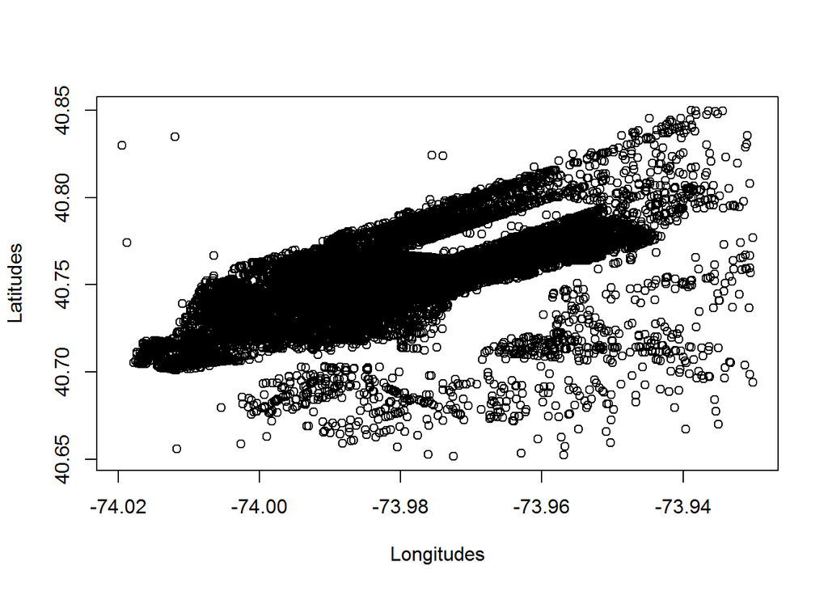

```r
pickLoc <- data.frame(pickLat=records$pickup_latitude,pickLon=records$pickup_longitude)
dropLoc <- data.frame(dropLat=records$dropoff_latitude,dropLon=records$dropoff_longitude)
pickLoc <- pickLoc[pickLoc$pickLat < 40.85 & pickLoc$pickLat > 40.65, ]
pickLoc <- pickLoc[pickLoc$pickLon < -73.93 & pickLoc$pickLon > -74.02, ]
dropLoc <- dropLoc[dropLoc$dropLat < 40.85 & dropLoc$dropLat > 40.65, ]
dropLoc <- dropLoc[dropLoc$dropLon < -73.93 & dropLoc$dropLon > -74.02, ]
x1 <- c(pickLoc$pickLon)
y1 <- c(pickLoc$pickLat)
x2 <- c(dropLoc$dropLon)
y2 <- c(dropLoc$dropLat)
x <- c(x1,x2)
y <- c(y1,y2)
gpsCordinates <- cbind(x,y)
plot(gpsCordinates, xlab="Longitudes", ylab="Latitudes")
```

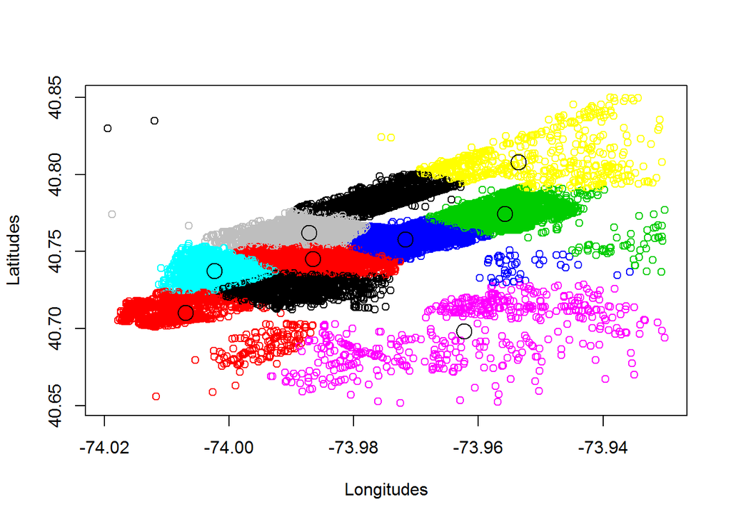

```r
# Since our data are cleaned, let's do the clustering now.
gpsCordinates <- cbind(x,y)
kc <- kmeans(gpsCordinates, 10)
plot(gpsCordinates, col=kc$cluster, xlab="Longitudes", ylab="Latitudes")
points(kc$centers,cex=2)
```

```r
# The GPS coordinates of the 10 busiest locations are
kc$centers
```

```
##            x        y
## 1  -73.98962 40.72657
## 2  -74.00700 40.71023
## 3  -73.95579 40.77466
## 4  -73.97178 40.75792
## 5  -74.00235 40.73753
## 6  -73.96232 40.69833
## 7  -73.95353 40.80795
## 8  -73.98722 40.76216
## 9  -73.97625 40.78457
## 10 -73.98656 40.74530
```

The above cluster centers are the busiest locations in NYC.

1.h) Which trip has the highest standard deviation of travel time?

To find this, I will find the trip having largest time difference to the mean of the travel time.

```r
travelTimeSD = (records$trip_time_in_secs - mean(records$trip_time_in_secs))^2

which.max(travelTimeSD)
```

```
## [1] 1145
```

```r
records[which.max(travelTimeSD),]
```

```
##       record_id                        medallion
## 98193  11771339 7FFEFED84D3F63B0E6ADD41DEFDBCE72
##                           hack_license vendor_id rate_code
## 98193 4DCA50F9B1CACC94B122FA631026E6E5       CMT         1
##       store_and_fwd_flag     pickup_datetime    dropoff_datetime
## 98193                  N 2013-04-03 12:07:44 2013-04-03 14:38:08
##       passenger_count trip_time_in_secs trip_distance pickup_longitude
## 98193               4              9022            24         -73.9863
##       pickup_latitude dropoff_longitude dropoff_latitude payment_type
## 98193         40.7592          -73.9794          40.7614          CSH
##       fare_amount surcharge mta_tax tip_amount tolls_amount total_amount
## 98193          86         0     0.5          0         5.33        91.83
##       pickup_datetime_transformed
## 98193         2013-04-03 12:07:44
```

1.i) Which trip has most consistent fares?

To find this, I will first check the distribution of the fare.

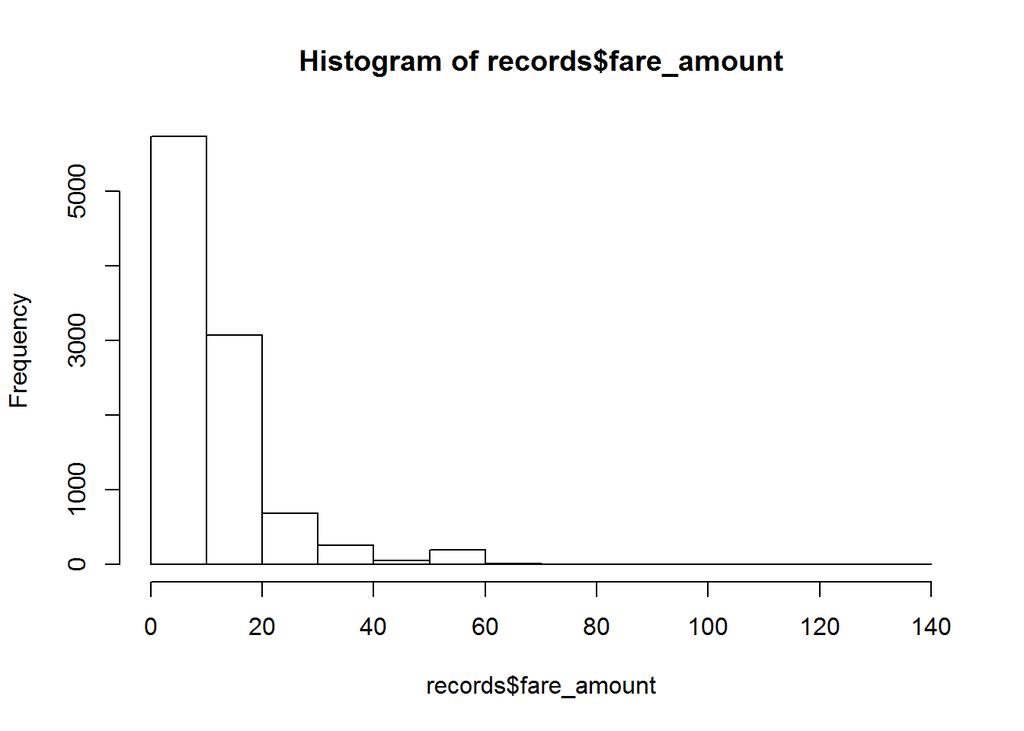

```r
hist(records$fare_amount)
```

```r
summary(as.factor(records$fare_amount))
```

```
##     6.5     7.5       7       6     5.5       5       8     8.5       9
##     537     521     493     487     477     452     437     421     394
##     4.5      10     9.5    10.5      11       4    11.5      12    12.5
##     380     354     351     322     280     246     246     232     225
##      13    13.5      14    14.5      52      15    15.5      16     3.5
##     205     193     178     174     172     144     129     125     120
##    16.5      17      18    17.5    18.5      19    19.5      20      21
##      98      91      88      79      75      70      62      53      52
##    20.5    21.5    22.5      22      23      24       3    23.5    24.5
##      48      48      48      43      42      40      38      35      34
##    25.5      28      26      25    26.5    27.5    28.5    30.5    29.5
##      32      31      30      29      29      29      28      27      24
##      30      27    31.5     2.5    32.5      35      31      33    36.5
##      23      22      22      18      16      16      15      15      15
##      32      39      29    35.5    34.5      34      37    33.5    38.5
##      14      14      13      13      12      11      11      10      10
##    37.5      36      38      40    40.5      43    44.5      41    43.5
##       9       8       8       6       6       6       6       5       4
##      44    45.5    41.5      45      47    47.5    52.5    54.5      57
##       4       4       3       3       3       3       3       3       3
##    39.5    42.5    50.5    51.5      61      67      42    46.5    48.5
##       2       2       2       2       2       2       1       1       1
## (Other)
##      30
```

```r
names(sort(summary(as.factor(records$fare_amount)), decreasing=T)[1])
```

```
## [1] "6.5"
```

The above is the most consistent fare. To find out what this trip is, let’s study the distance and travel time corresponding to that fare.

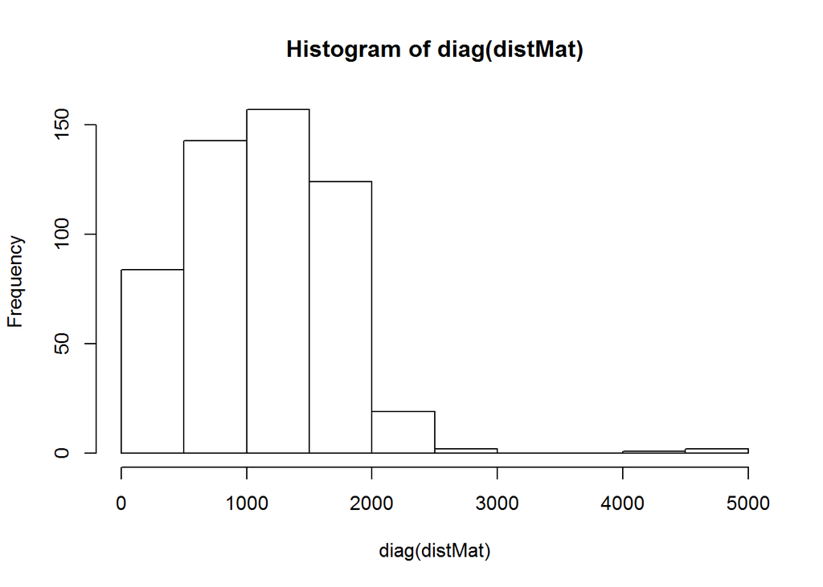

```r
consistentTime <- names(sort(summary(as.factor(records$fare_amount)), decreasing=T)[1]);
tripFare  <- data.frame(pickLat=records$pickup_latitude,pickLon=records$pickup_longitude,
                        dropLat=records$dropoff_latitude,dropLon=records$dropoff_longitude,
                        fare=records$fare_amount)
tripFare  <- tripFare[tripFare$pickLat!=0 & tripFare$pickLon!=0, ]
tripFare  <- tripFare[tripFare$dropLat!=0 & tripFare$dropLon!=0, ]
tripFare  <- tripFare[tripFare$fare==consistentTime, ]
x1 <- c(tripFare$pickLon)
y1 <- c(tripFare$pickLat)
x2 <- c(tripFare$dropLon)
y2 <- c(tripFare$dropLat)

distMat <- distm (cbind(y1,x1), cbind(y2,x2), fun = distHaversine);
hist(diag(distMat))
```

```r
summary(diag(distMat))
```

```
##    Min. 1st Qu.  Median    Mean 3rd Qu.    Max.
##     0.0   715.5  1112.1  1134.1  1532.5  4831.1
```

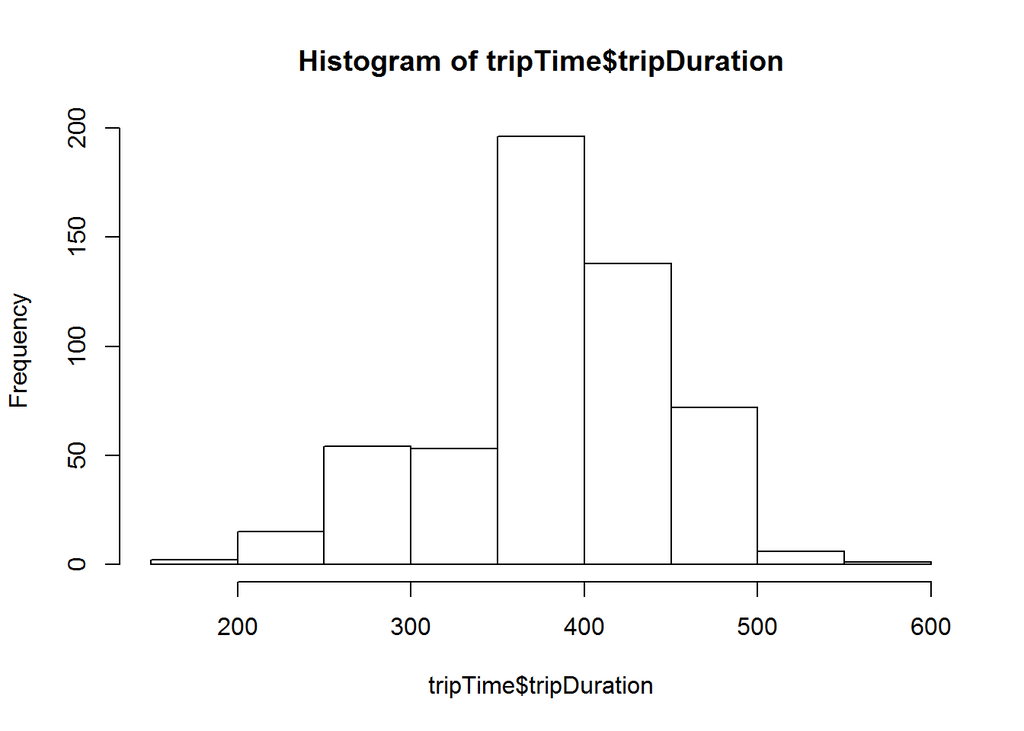

```r
tripTime <- data.frame(tripDuration=records$trip_time_in_secs, fare=records$fare_amount)
tripTime <- tripTime[tripTime$fare==consistentTime,]
hist(tripTime$tripDuration)
```

```r
summary(tripTime$tripDuration)
```

```
##    Min. 1st Qu.  Median    Mean 3rd Qu.    Max.
##   180.0   354.0   372.0   382.7   420.0   600.0
```

As per the distributions of distance and time, this fare is for regular short trips. Mean of the distance and time has been calculated above. They are approximately 1km trips of around 6 minutes. This may be confirmed by the corresponding pickup and dropoff locations where all are within the city.

Pickup Locations

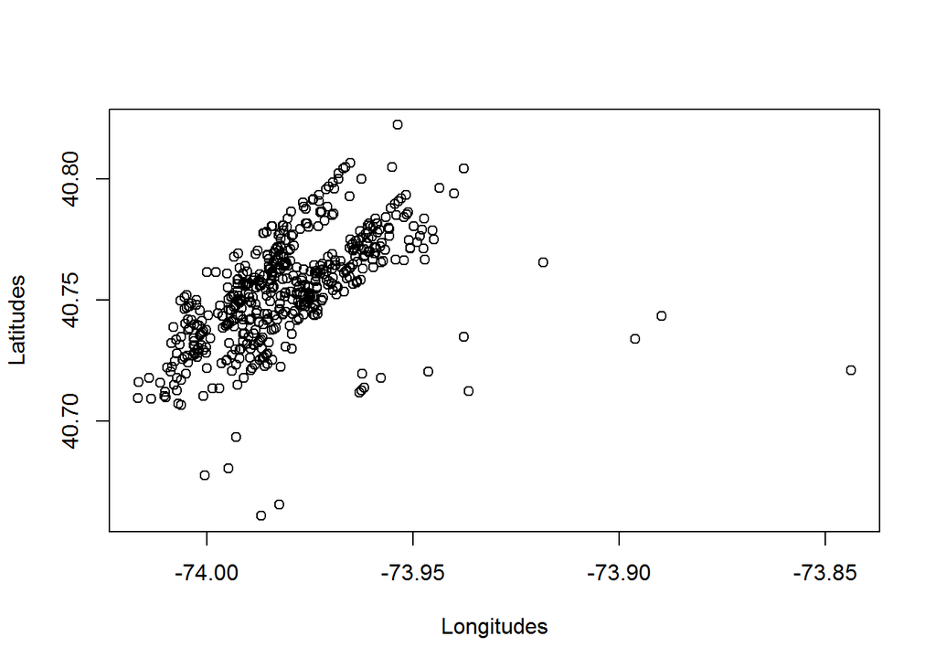

```r
gpsPickCordinates <- cbind(x1,y1)
plot(gpsPickCordinates, xlab="Longitudes", ylab="Latitudes")
```

Dropoff Locations

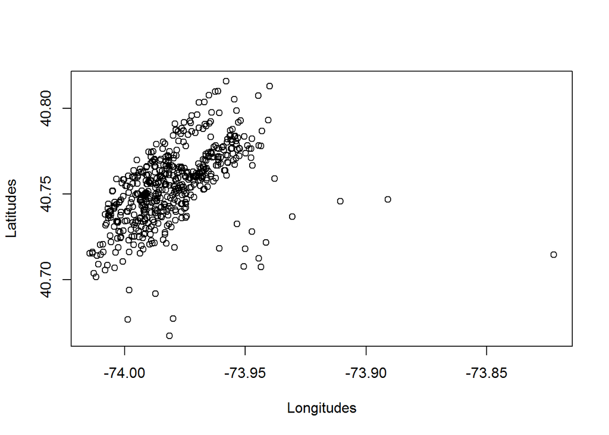

```r
gpsDropCordinates <- cbind(x2,y2)
plot(gpsDropCordinates, xlab="Longitudes", ylab="Latitudes")
```

## Analysis of NYC Taxi Data

In this section, we explain some modeling techniques we applied to understand the NYC Taxi data. We applied Bootstrap method wherever possible to improve the accuracy of the results. The main data file has 100,000 rows, which will be randomly sampled 10,000 rows several times to improve the accuracy.

```r
filename <- "sampledData100000.csv";
records  <- read.csv(filename);

library(lubridate)
library(geosphere)
library(ggplot2)
```

### 2.a) In what trips can you confidently use respective means as measures of central tendency to estimate fare, time taken, etc.

In statistics, the measures of central tendencies are Mean, Median, Mode, etc. For example, if a sample is close to Mean of the population mean, then that sample can represent the population with high confidence level. However, analyzing the entire population is not possible.

The Central Limit Theorem states that the sampling distribution of the sampling means approaches a normal distribution as the sample size gets larger and typically over 30. Further, the mean of the distribution of the sample mean is closer to the population mean.

Therefore, we should select trips where their features sampling means are a normal distribution. However, this is only for representation. To increase the confidence, the values of the sample features should be closer to the mean of the sample mean distribution.

To demonstrate this, we selected Fare feature. We randomly picked 10000 samples 100 times from 100,000 data set. Then we plotted the distribution of the mean of the sample fare set.

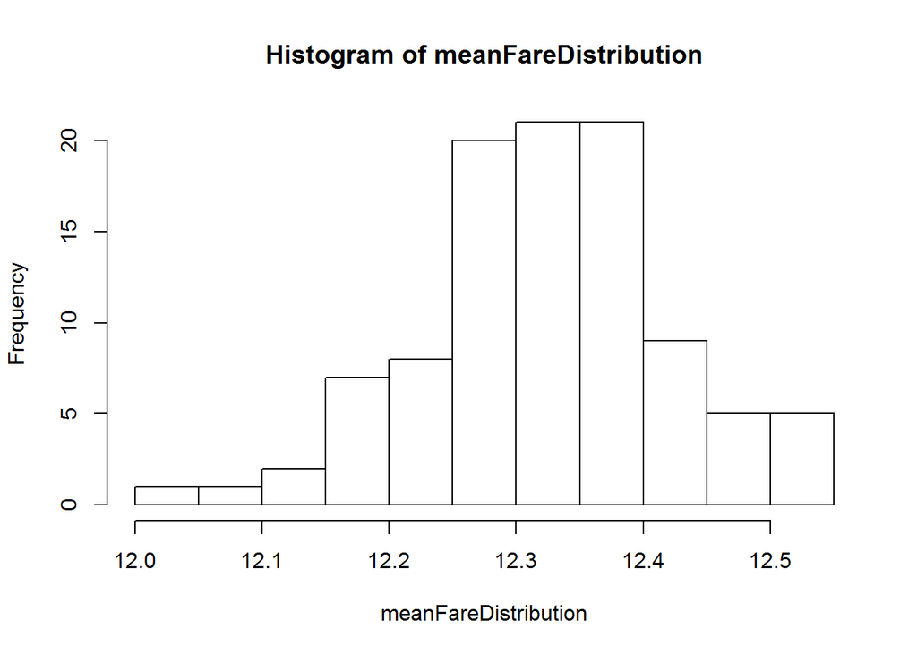

```r
maxItter <- 100
numSamples <- 10000

meanFareDistribution <- array(maxItter)
for (i in c(1:maxItter)){
  sampleData <- records[sample(1:nrow(records), numSamples, replace=FALSE),]

  requestedData <- sampleData$fare_amount
  meanFareDistribution[i] <- mean(requestedData)
}
hist(meanFareDistribution)
```

```r
summary(meanFareDistribution)
```

```
##    Min. 1st Qu.  Median    Mean 3rd Qu.    Max.
##   12.03   12.27   12.32   12.32   12.38   12.54
```

As per the distribution summary, the mean of the distribution of the means is ~12.3 dollars. Then we can say, the trips having fare closer to 12.3 dollars represent the central tendency respective to the fare. This might not be true related to a different feature.

### 2.b) Can we build a model to predict fare and tip amount given pick up and drop off coordinates, time of day and week?

First of all we prepared the data for the model. Here we extracted the day of the week and hour of the day from the pickup_datetime. We created lmData data frame for processing. It has fare, pickLat , pickLon , dropLat , dropLon , day , hour.

```r
lmData  <- data.frame(fare=records$fare_amount, tip=records$tip_amount, tripDuration=records$trip_time_in_secs,
                      pickLat=records$pickup_latitude,pickLon=records$pickup_longitude,
                      dropLat=records$dropoff_latitude,dropLon=records$dropoff_longitude,
                      day=wday(records$pickup_datetime), hour=hour(records$pickup_datetime))
```

Then we cleaned the data. For that we plotted the distribution of each.

```r
attach(mtcars)
```

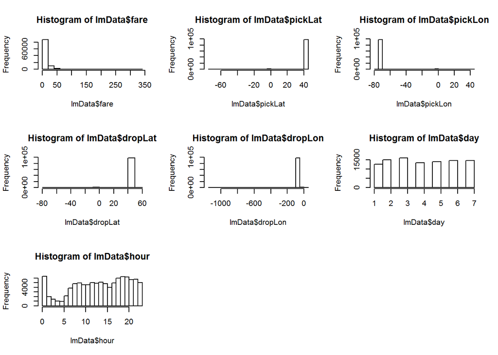

```r
par(mfrow=c(3,3))
hist(lmData$fare)
hist(lmData$pickLat)
hist(lmData$pickLon)
hist(lmData$dropLat)
hist(lmData$dropLon)
hist(lmData$day)
hist(lmData$hour)
```

Those data are not properly distributed for modelling. Data has high skewness. We are now cleaning and transforming the data for proper distribution. Otherwise, the outliers will impact on the model.

We remove wrong GPS locations which are clearly data entry errors. We also removed trips having same pickup and dropoff locations. We then forcus on the high taxi demand areas by limiting the GPS coordinates. Since fare has high variation, we forcus on the most consistent fares as very high fare from a single trip is rare.

```r
lmData <- lmData[lmData$fare<20, ]
lmData <- lmData[lmData$pickLat < 40.85 & lmData$pickLat > 40.65, ]
lmData <- lmData[lmData$dropLat < 40.85 & lmData$dropLat > 40.65, ]
lmData <- lmData[lmData$pickLon < -73.93 & lmData$pickLon > -74.02, ]
lmData <- lmData[lmData$dropLon < -73.93 & lmData$dropLon > -74.02, ]
lmData <- lmData[lmData$pickLat!=lmData$dropLat & lmData$pickLon!=lmData$dropLon, ]

attach(mtcars)
```

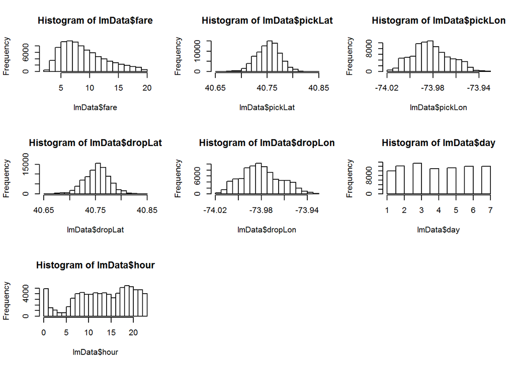

```r
par(mfrow=c(3,3))
hist(lmData$fare)
hist(lmData$pickLat)
hist(lmData$pickLon)
hist(lmData$dropLat)
hist(lmData$dropLon)
hist(lmData$day)
hist(lmData$hour)
```

Now we focus on the data related to Tip. First, let’s study the distribution of the Tip.

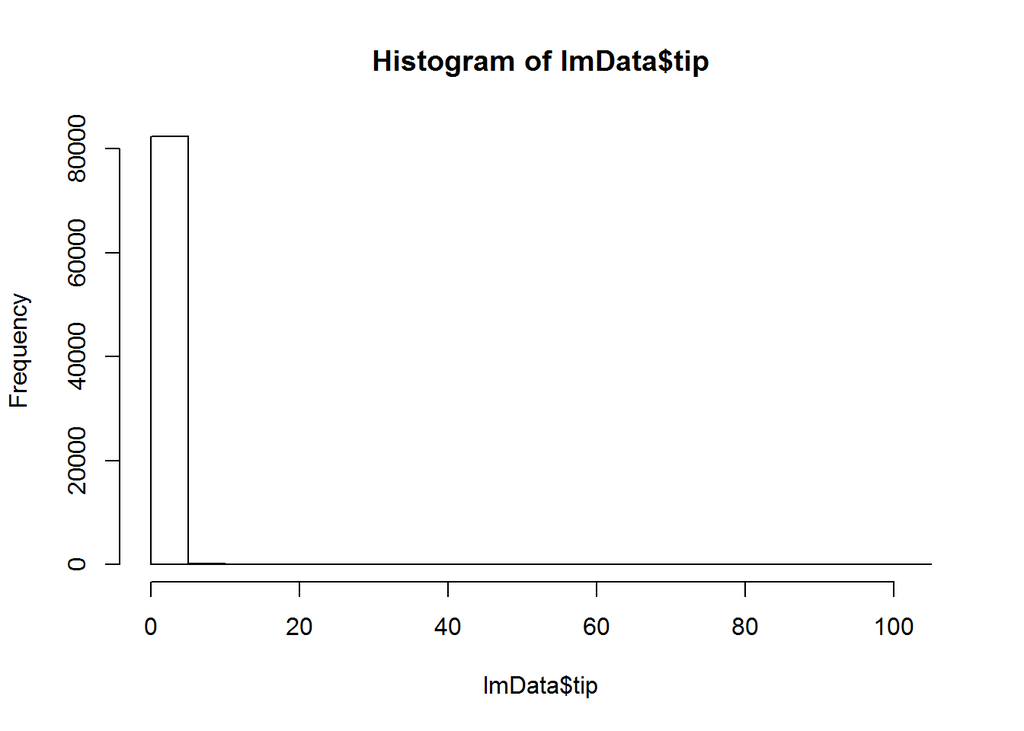

```r
hist(lmData$tip)
```

It seems the Tip is highly right skewed. Further, most tips are 1 dollar tips. Here we assume we want to predict tips greater than 1 dollar as having a 1 dollar tip is very common. We selected the most consistent tips other than 1 dollar. Then we applied log function to transform the Tip closer to normal distribution. We identified this transformation to transform the distribution closer to normal. Another advantage of applying log function to deskew the distribution is that reverse transformation is straightforward and easy. The new distribution of the Tip is as follows:

```r
attach(mtcars)
```

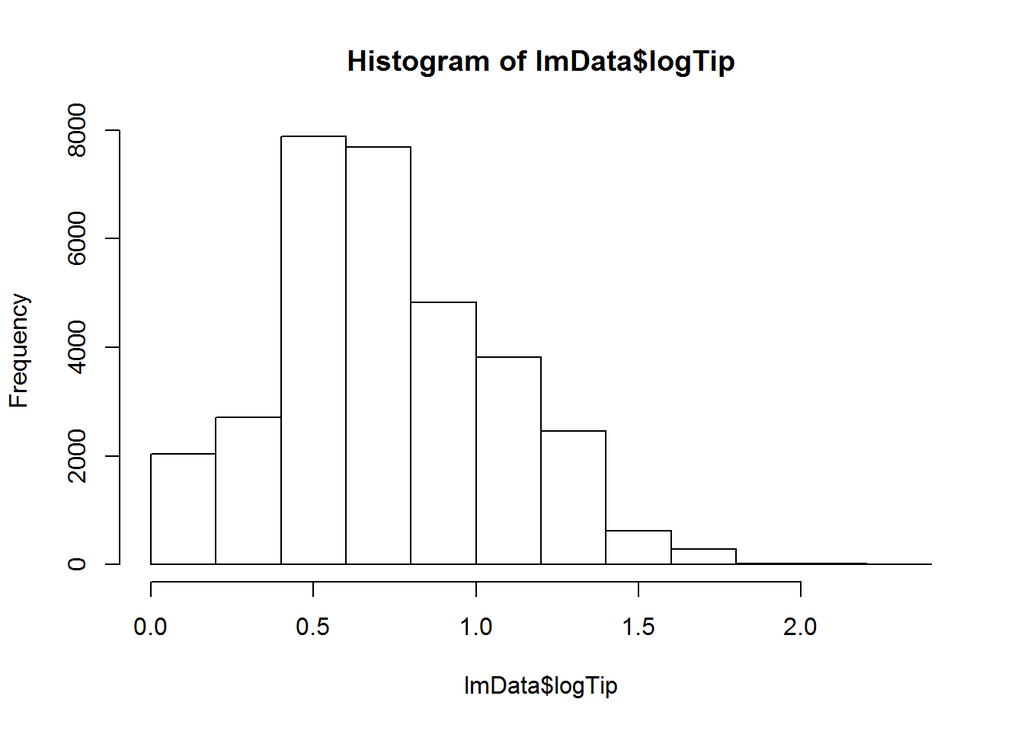

```r
lmData <- lmData[lmData$tip<10 & lmData$tip>1, ]
lmData$logTip <- log(lmData$tip);
hist(lmData$logTip)
```

Now data are ready for modeling. First, start with the fare. Let’s run a linear model and summarize the results. Note here we run the modeling process 100 times to improve the reliability.

```r
maxItter <- 100
numSamples <- 10000

modelFareDistribution <- array(maxItter)
for (i in c(1:maxItter)){

  lmDataSampled <- lmData[sample(1:nrow(lmData), numSamples, replace=FALSE),]

  myModelFare  <- lm(fare ~ pickLat + pickLon + dropLat + dropLon + day + hour, data=lmDataSampled)
  modelFareDistribution[i] <- summary(myModelFare)$r.squared
}
summary(myModelFare)
```

```
##
## Call:
## lm(formula = fare ~ pickLat + pickLon + dropLat + dropLon + day +
##     hour, data = lmDataSampled)
##
## Residuals:
##     Min      1Q  Median      3Q     Max
## -8.9255 -2.9465 -0.5847  2.5159 10.3931
##
## Coefficients:
##               Estimate Std. Error t value Pr(>|t|)
## (Intercept)  3.018e+03  3.330e+02   9.063   <2e-16 ***
## pickLat     -2.743e+00  2.415e+00  -1.136    0.256
## pickLon      3.165e-01  3.161e+00   0.100    0.920
## dropLat     -2.209e+01  2.107e+00 -10.483   <2e-16 ***
## dropLon      2.667e+01  2.757e+00   9.672   <2e-16 ***
## day          8.532e-02  1.931e-02   4.419    1e-05 ***
## hour         3.530e-04  5.723e-03   0.062    0.951
## ---
## Signif. codes:  0 '***' 0.001 '**' 0.01 '*' 0.05 '.' 0.1 ' ' 1
##
## Residual standard error: 3.735 on 9993 degrees of freedom
## Multiple R-squared:  0.01944,    Adjusted R-squared:  0.01885
## F-statistic: 33.02 on 6 and 9993 DF,  p-value: < 2.2e-16
```

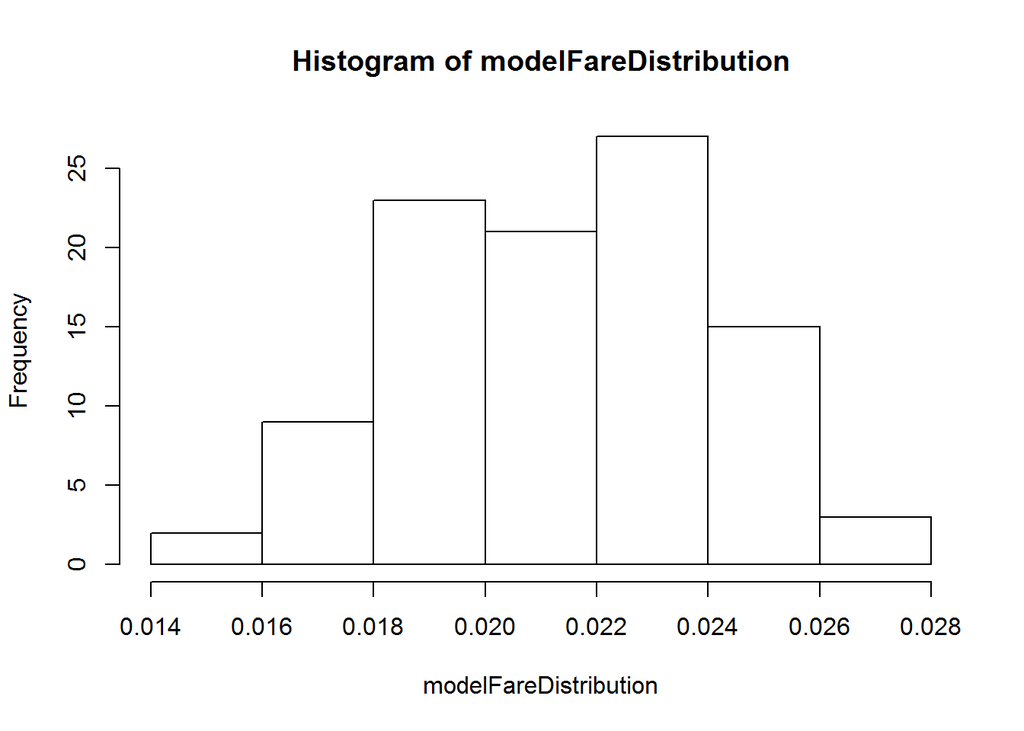

```r
hist(modelFareDistribution)
```

R-squared = 1 - (sum((actual-predict )<sup>2)/sum((actual-mean(actual))</sup>2)),

Where closer to 1 is desirable.

```r
attach(mtcars)
```

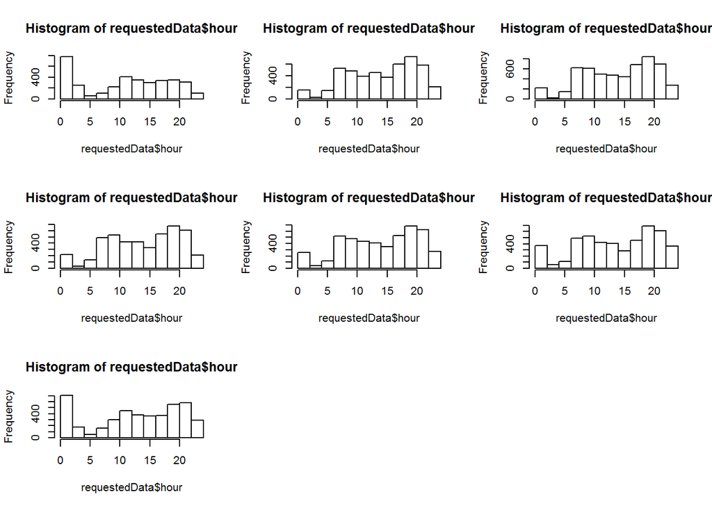

```r
par(mfrow=c(3,3))
requestedData <- lmData[lmData$day==1,]
hist(requestedData$hour)
requestedData <- lmData[lmData$day==2,]
hist(requestedData$hour)
requestedData <- lmData[lmData$day==3,]
hist(requestedData$hour)
requestedData <- lmData[lmData$day==4,]
hist(requestedData$hour)
requestedData <- lmData[lmData$day==5,]
hist(requestedData$hour)
requestedData <- lmData[lmData$day==6,]
hist(requestedData$hour)
requestedData <- lmData[lmData$day==7,]
hist(requestedData$hour)
```